# error_analysis_hcr30

Sara Orofino

1/13/2020

## Setup

```r
knitr::opts_chunk$set(echo = TRUE)

#Packages
library(tidyverse)
library(here)
library(RColorBrewer)
library(kableExtra)

#Data
err_rep5u <- read_csv(file=file.path(here(),"/Results/error/error_updating_rep5_hcr30.csv"))
err_rep10u <- read_csv(file=file.path(here(),"/Results/error/error_updating_rep10_hcr30.csv"))
err_rep5c <- read_csv(file=file.path(here(),"/Results/error/error_constant_rep5_hcr30.csv"))
err_rep10c <- read_csv(file=file.path(here(),"/Results/error/error_constant_rep10_hcr30.csv"))


#Comparision of perfect management data
perfect <- read_csv(file=file.path(here(),"/Tests/perfect_management/csv_results/perfect_r0.1.csv"))
perfect_fishe <- read_csv(file=file.path(here(),"/Results/error/perfect_updating_rep5_hcr30.csv"))
```

## Cumulative Yield Example

### Slow Growing

Initial Conditions of Experiment: - b0 = 4000 - r = 0.2 - r_s = -0.01767 - error = 0.1

Perfect Management: ID = 8 Perfect given FISHE: ID = 5 Error: ID = 5, 413, 821

```
## [1] 47278.17
```

```
## [1] 31461.16
```

```
## [1] 31333.4
```

```
## [1] 30458.11
```

```
## [1] 25253.79
```

### Fast Growing

Initial Conditions of Experiment: - b0 = 4000 - r = 0.8 - r_s = -0.01767 - error = 0.1

Perfect Management: ID = 44 Perfect given FISHE: ID = 23 Error: ID = 23, 431, 839

```
## [1] 118751.8
```

```
## [1] 125718.5
```

```
## [1] 125319.8
```

```
## [1] 123694.9
```

```
## [1] 0
```

## Slow Comparison Graph

Graph biomass and catch over time for perfect management, perfect given FISHE, and the error simulation:

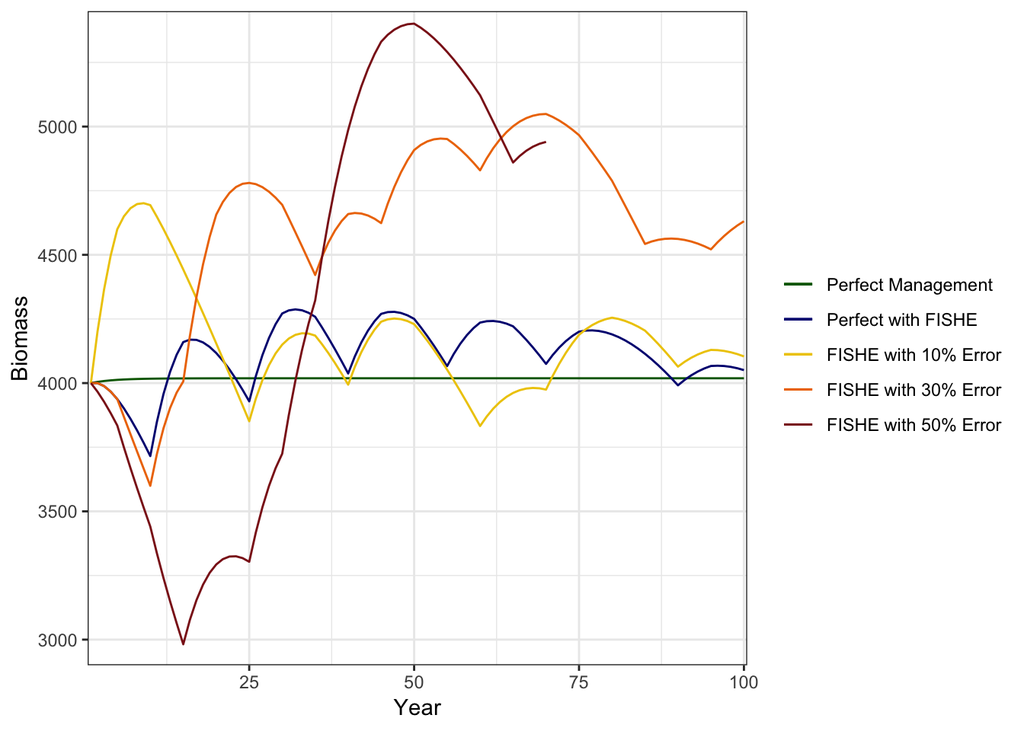

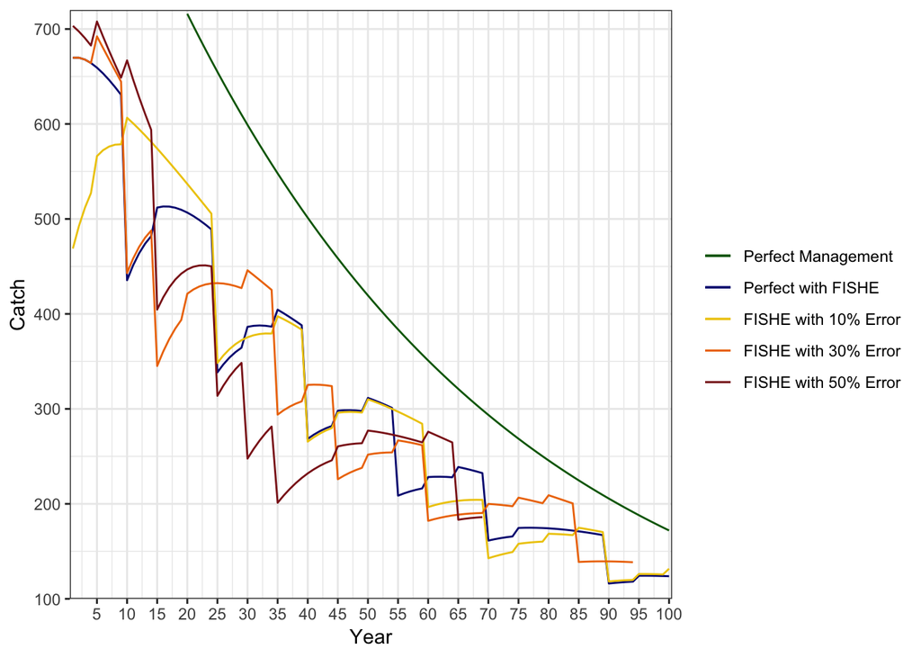

## Fast Comparison Graph

Graph biomass and catch over time for perfect management, perfect given FISHE, and the error simulation:

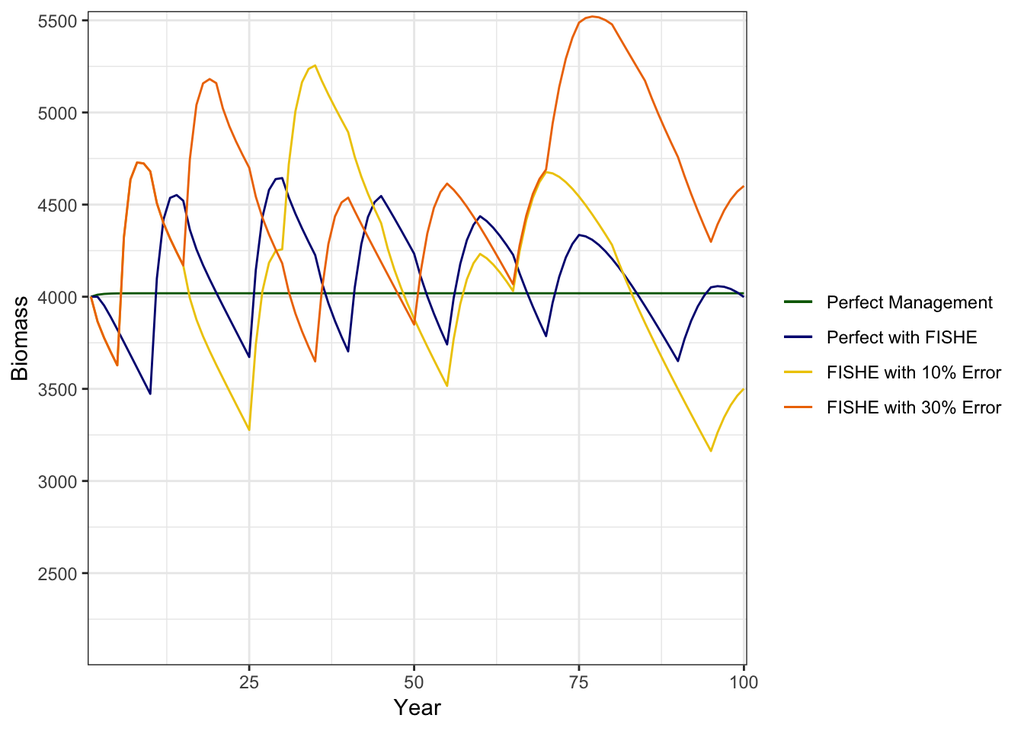

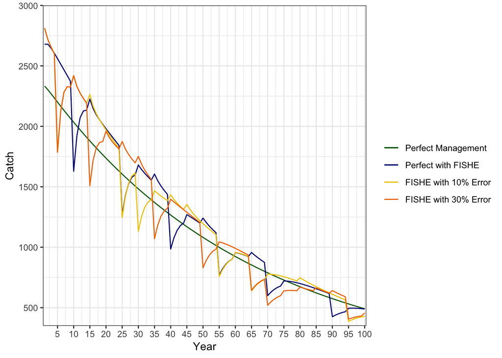

## Aggregated Cumulative Yields

Going to try calculating cumulative yields under the most aggressive climate change decline by aggregating slow growing (r = 0.1-0.3), intermediate (r=0.4-0.5), and fast growing (r=0.6-0.8). For now I’m including all three starting biomasses.

### Slow Growing

Defining slow growing as having growth rates between 0.1 and 0.3. Find cumulative yields for perfect, perfect given FISHE, and the three error scenarios

Steps:  
- Filter for climate change r_s = -0.01767  
- Filter for growth rates less than 0.3  
- Group by Id and calculate cumulative yield (sum of catch for that experiment)  
- Find the average catch for all the experiments

UPDATING FMSY:

Make a formal table:  
We are scratching the percect perfect thing and I just want to make a table comparing updating and constant fmsy percent bad outcomes. I’ll create the dataframe from other wrangling I did above and then make a table.

|  | 10% Error | 30% Error | 50% Error |
| --- | --- | --- | --- |
| constant fmsy | 0.7883598 | 0.7936508 | 0.7037037 |
| updating fmsy | 0.2751323 | 0.5555556 | 0.6349206 |

### Intermediate Growing

Defining intermediate growing as having growth rates between 0.4 and 0.5. Find cumulative yields for perfect, perfect given FISHE, and the three error scenarios

Steps:  
- Filter for climate change r_s = -0.01767  
- Filter for growth rates between 0.4 and 0.5  
- Group by Id and calculate cumulative yield (sum of catch for that experiment)  
- Find the average catch for all the experiments

CONSTANT FMSY:  
It’s important to compare these updating fmsy results to the constant fmsy results since that seemed really important in other experiments  
Note: I only copied the code for the first type of table but I can easily do the second type of table if that’s the preferred one

Make a formal table:

|  | 10% Error | 30% Error | 50% Error |
| --- | --- | --- | --- |
| constant fmsy | 0.8174603 | 0.8412698 | 0.7936508 |
| updating fmsy | 0.3174603 | 0.4206349 | 0.3253968 |

### Fast Growing

Defining fast growing as having growth rates of 0.6 or greater. Find cumulative yields for perfect, perfect given FISHE, and the three error scenarios

Steps:  
- Filter for climate change r_s = -0.01767  
- Filter for growth rates greater than 0.6  
- Group by Id and calculate cumulative yield (sum of catch for that experiment)  
- Find the average catch for all the experiments

CONSTANT FMSY:  
It’s important to compare these updating fmsy results to the constant fmsy results since that seemed really important in other experiments  
Note: I only copied the code for the first type of table but I can easily do the second type of table if that’s the preferred one

Make a formal table:

|  | 10% Error | 30% Error | 50% Error |
| --- | --- | --- | --- |
| constant fmsy | 0.8412698 | 0.7830688 | 0.7619048 |
| updating fmsy | 0.2222222 | 0.4074074 | 0.7407407 |